# Firm size distribution

Use `sample_size_tb` to examine the distributions of firm age and sales, sales distributions by year, and how close log sales are to a normal distribution. Calculate the shares of each age class among firms aged 50 or younger whose sales exceed a specified threshold.

## 1 Distributions of firm age and sales

```r
library(tidyverse)
library(pins)
library(hrbrthemes)
theme_set(theme_ipsum(base_size = 12, axis_title_size = 13))
board <- board_folder("../Zipf_law_board_replicate_simulation")
```

**Loading data and creating age classes**

Load the data and calculate firm age `age` as observation year `year` minus establishment year `birth_year`. Use observations meeting the following conditions.

- Positive sales `sale`
- Observation year from 2010 through 2020
- The first two digits of industry code `ind_class` are 01–61 or 68–92

Add sales in yen as `sale_yen` to the plotting dataset `sample_size_yen_tb`, calculated by multiplying `sale`, measured in thousands of yen, by 1000.

```r
sample_size_tb <- board |> pin_read("sample_size_tb", type = "qs2") |>
  mutate(age = as.numeric(year) - birth_year) |>
  filter(sale > 0,
         as.numeric(year) >= 2010, as.numeric(year) <= 2020,
         str_sub(ind_class, 1,2) %in% str_pad(c(1:61, 68:92), 2, pad = 0))

# Retain the original sale and add a yen-denominated column for plotting and composition calculations.
sample_size_yen_tb <- sample_size_tb |>
  mutate(sale_yen = sale * 1000)
```

Create `size_20_tb` restricted to 2020 and classify firm age into five-year intervals in `age_class`. The first class covers ages 0–5, followed by 6–10, 11–15, …, 91–95. Assign firms older than 95 to `age_95_over`. Assign firms with missing or negative ages to `age_other`.

Also create `size_20_yen_tb` with sales in yen and age classifications. Define `age_group` as minus for negative ages, young for ages 0–50, middle for ages above 50 through 70, old for ages above 70, and other otherwise.

```r
size_20_tb <- sample_size_tb |>
  filter(year == "2020") |>
  mutate(
    age_class = cut(
      age,
      breaks = c(seq(0, 95, by = 5), Inf),  # 0–5, ..., 91–95, 96+
      right = TRUE,
      labels = c(
        str_c("age_", str_pad(seq(5, 95, by = 5), 2, pad = "0")),
        "age_95_over"
      ),
      include.lowest = TRUE
    ),
    age_class = if_else(is.na(age_class) | age < 0, "age_other", age_class)
  )

age_class_labels <- c(
  "age_05" = "0–5",   "age_10" = "6–10",  "age_15" = "11–15", "age_20" = "16–20",
  "age_25" = "21–25", "age_30" = "26–30", "age_35" = "31–35", "age_40" = "36–40",
  "age_45" = "41–45", "age_50" = "46–50", "age_55" = "51–55", "age_60" = "56–60",
  "age_65" = "61–65", "age_70" = "66–70", "age_75" = "71–75", "age_80" = "76–80",
  "age_85" = "81–85", "age_90" = "86–90", "age_95" = "91–95", "age_95_over" = "96+"
)

size_20_yen_tb <- size_20_tb |>
  mutate(
    sale_yen = sale * 1000,
    age_group = case_when(
      age < 0 ~ "minus",
      0 <= age & age <= 50 ~ "young",
      age > 50 & age <= 70 ~ "middle",
      age > 70 ~ "old",
      TRUE ~ "other"
    ),
    age_group = factor(
      age_group,
      levels = c("minus", "young", "middle", "old", "other")
    )
  )
```

```r
size_20_yen_tb |> count(age_group, name = "n_obs")
```

| age_group | n_obs |
| --- | --- |
| young | 164054 |
| middle | 64373 |
| old | 32164 |

Plot a histogram with one-year bins for observations with firm ages from 0 to 120.

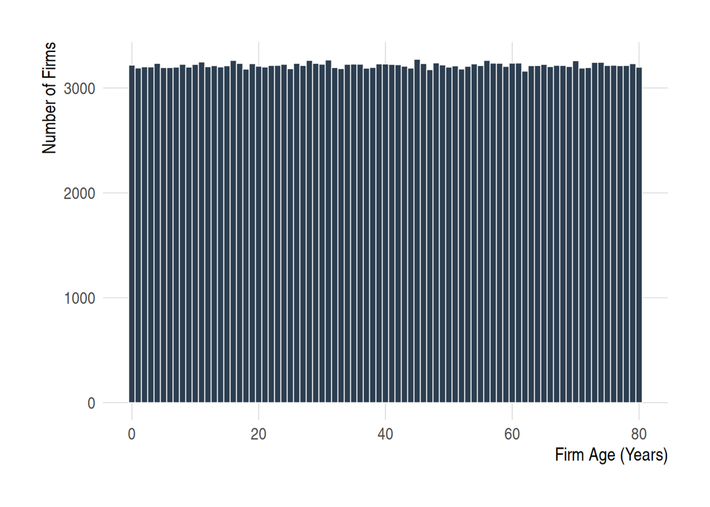

```r
size_20_tb |>
  filter(age_class != "age_other",
         age >= 0, age <= 120) |>
  ggplot(aes(x = age)) +
  geom_histogram(binwidth = 1, fill = "#2C3E50", color = "white", linewidth = 0.3) +
  labs(
    x = "Firm Age (Years)",
    y = "Number of Firms"
  ) +
  theme(
    panel.grid.minor = element_blank(),
    axis.title = element_text(face = "bold")
  )
ggsave(filename = "age_dist.png", path = "graph")
```

**Sales distributions by age**

First plot the full 2020 sample, then compare the three groups young, middle, and old.

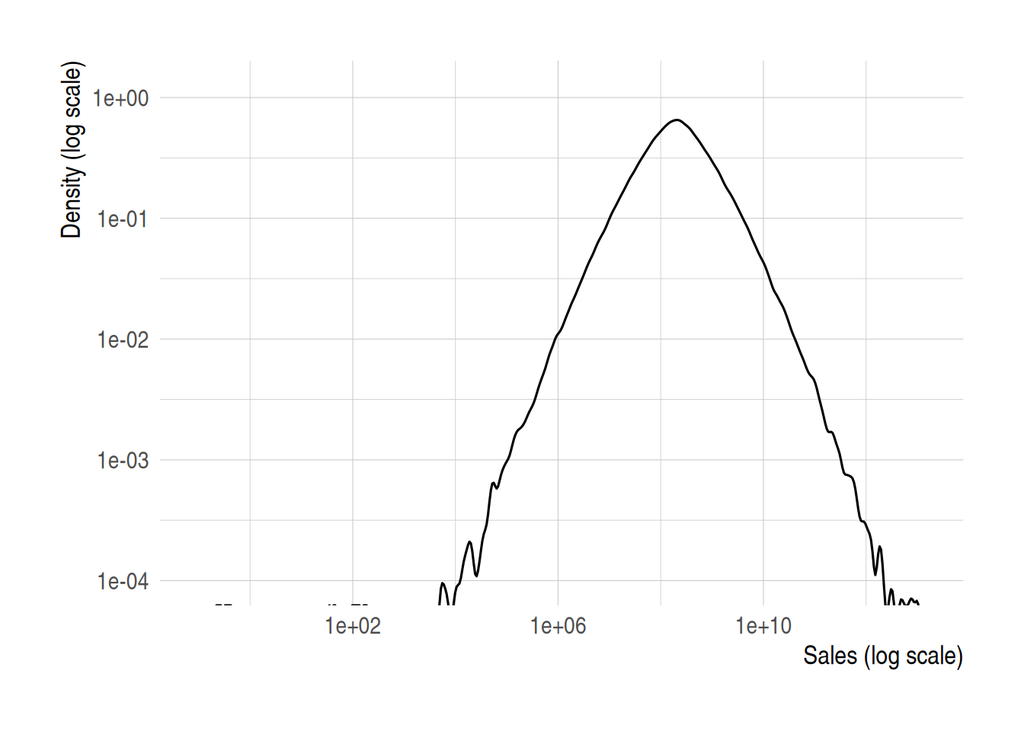

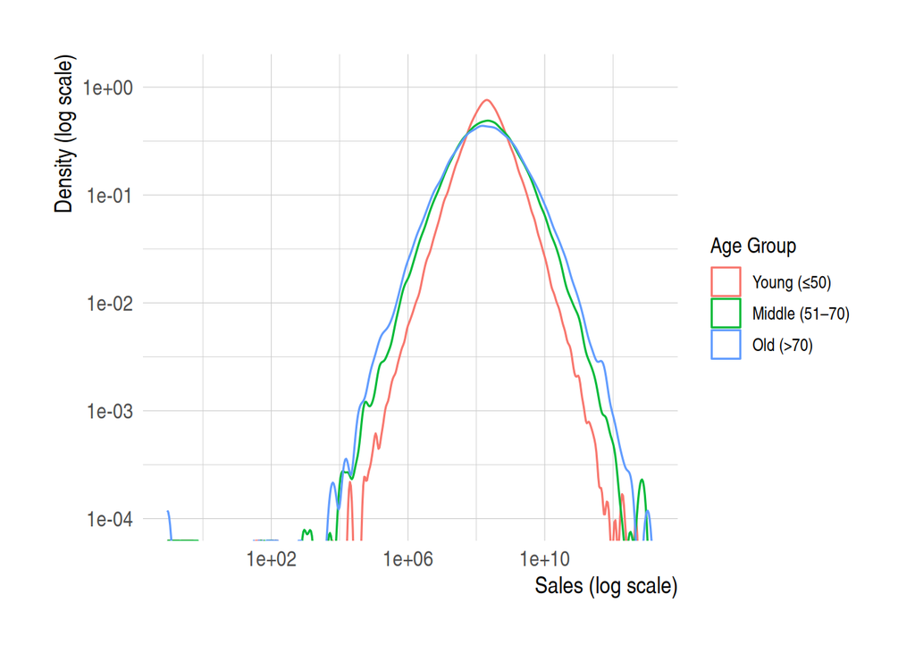

```r
# Shared density plot for data containing sales in yen as sale_yen.
plot_size_density <- function(data, color_var = NULL) {
  p <- ggplot(data, aes(x = sale_yen))

  if (!is.null(color_var)) {
    p <- p + aes(color = .data[[color_var]])
  }

  p +
    geom_density() +
    scale_x_log10() +
    scale_y_log10() +
    coord_cartesian(ylim = c(10^-4, 10^0.1)) +
    labs(
      x = "Sales (log scale)",
      y = "Density (log scale)"
    ) +
    theme(axis.title = element_text(face = "bold"))
}

plot_size_density(size_20_yen_tb)
ggsave(filename = "size_df_agg.png", path = "graph")

size_20_yen_tb |>
  filter(age_group %in% c("young", "middle", "old")) |>
  plot_size_density("age_group") +
  scale_color_discrete(labels = c(
    young = "Young (≤50)", middle = "Middle (51–70)", old = "Old (>70)"
  )) +
  labs(color = "Age Group")
ggsave(filename = "size_df_three_age_group.png", path = "graph")
```

Compare sales distributions across five-year `age_class` intervals. Use the shared function’s logarithmic axes, density estimation, and displayed vertical range for all figures.

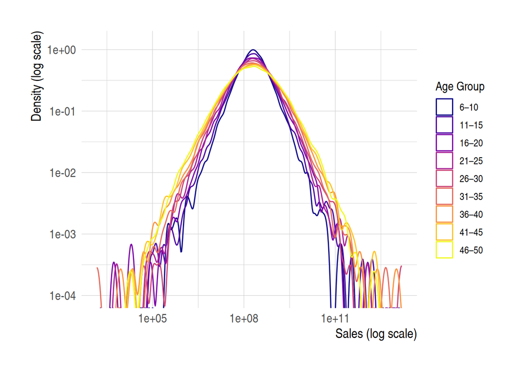

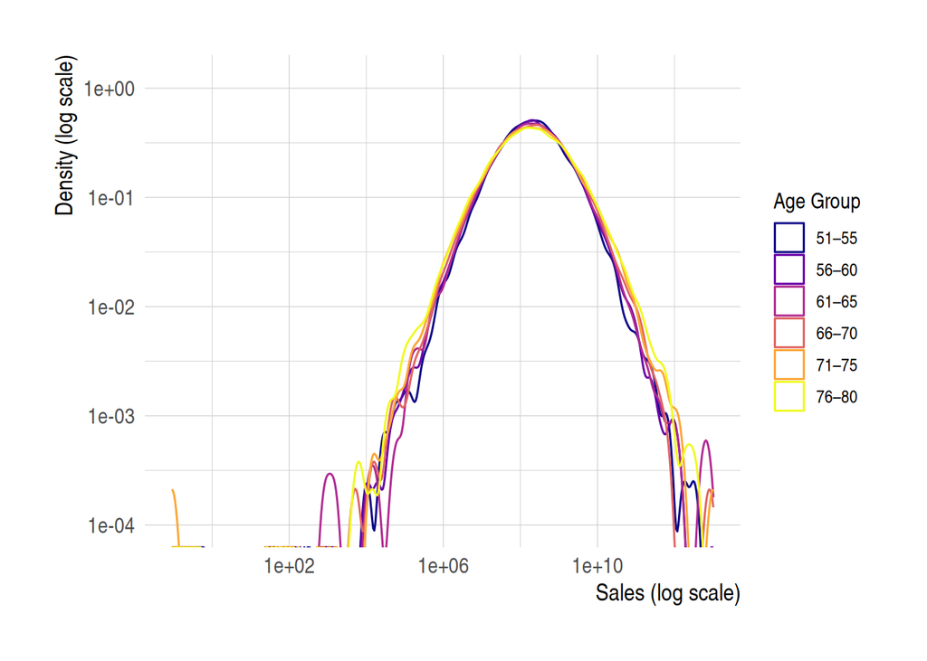

```r
size_20_yen_tb |>
  filter(age > 5, age <= 50) |>
  plot_size_density("age_class") +
  scale_color_viridis_d(option = "C", labels = age_class_labels) +
  labs(color = "Age Group")
ggsave(filename = "size_df_young.png", path = "graph")

size_20_yen_tb |>
  filter(age > 50) |>
  plot_size_density("age_class") +
  scale_color_viridis_d(option = "C", labels = age_class_labels) +
  labs(color = "Age Group")
ggsave(filename = "size_df_old.png", path = "graph")
```

**Annual comparison of sales distributions**

Using the 2010–2020 data selected when loading, compare density curves for sales in yen, colored by year. Impose no additional age restrictions and use the shared function’s logarithmic axes and display ranges.

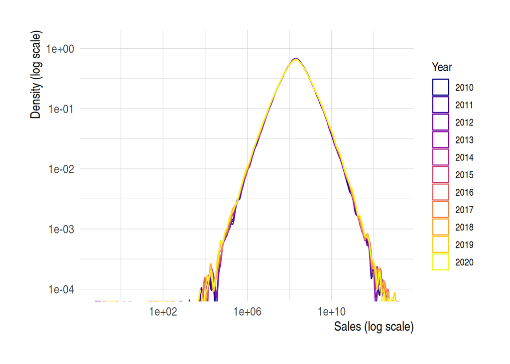

```r
# The 2010–2020 restriction was already applied when loading the data.
sample_size_yen_tb |>
  plot_size_density("year") +
  scale_color_viridis_d(
    option = "C",
    labels = age_class_labels
  ) +
  labs(color = "Year")
ggsave(filename = "size_df_agg_diff_year.png", path = "graph")
```

## 2 Comparing log sales with a normal distribution: Q-Q plots

Select age classes `age_10`, `age_20`, …, `age_90` from the 2020 data. For each class, take the natural logarithm of the original sales measured in thousands of yen, subtract the median of these log sales, and divide by their MAD (median absolute deviation).

Use Q-Q plots to compare sample quantiles of standardized log sales with theoretical quantiles of the standard normal distribution. Add a reference line with intercept zero and slope one.

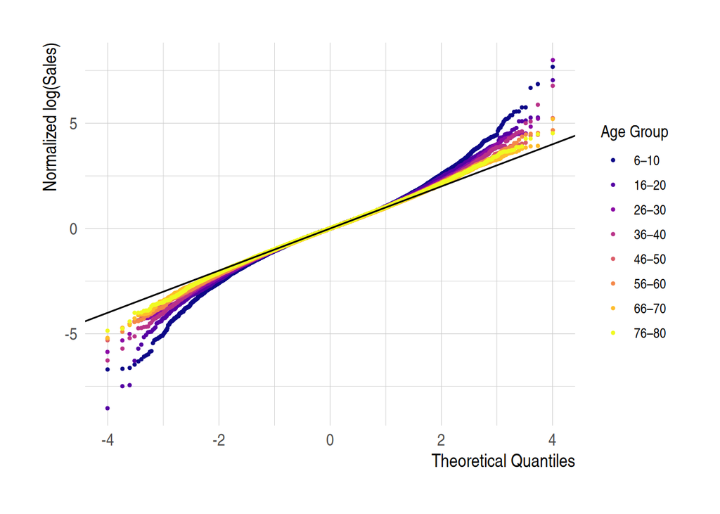

```r
size_20_tb |>
  filter(age_class %in% str_c("age_", str_pad(seq(10, 90, 10), width = 2, pad = "0")),
         sale > 0) |>
  group_by(age_class) |>
  mutate(log_sale = log(sale),
         log_sale_normalized = (log_sale - median(log_sale))/mad(log_sale) ) |>
ggplot(aes(sample = log_sale_normalized, color = age_class)) +
  stat_qq(size = 0.7) + #stat_qq_line() +
  scale_color_viridis_d(
    option = "C",
    labels = age_class_labels) +
  geom_abline(intercept = 0, slope = 1, color="black") +
  labs(
    x = "Theoretical Quantiles",
    y = "Normalized log(Sales)",
    color = "Age Group"
  ) +
  theme(axis.title = element_text(face = "bold"))
ggsave(filename = "size_qqplot_by_age.png", path = "graph")
```

## 3 Age composition by sales threshold

For firms aged 50 or younger in 2020, examine the age composition of firms whose sales exceed a threshold.

Set sales thresholds in yen to $10^9, 10^{9.2}, \ldots, 10^{14}$, giving 26 points spaced by 0.2 in base-10 logarithms. For each threshold, select observations strictly above that value and calculate composition shares `n_ratio`, using the total count as the denominator and the count in each age class as the numerator.

```r
x_val <- 10^seq(9.0, 14, 0.2)

compute_frac_tb <- function(df, thresholds) {
  map_dfr(thresholds, function(threshold) {
    sub_tb <- df |> filter(sale_yen > threshold)
    n_total <- nrow(sub_tb)
    if (n_total == 0) return(NULL)

    sub_tb |>
      group_by(age_class) |>
      summarise(n_ratio = n() / n_total, .groups = "drop") |>
      mutate(criteria = threshold, n_total = n_total)
  })
}

# Apply the age restriction first. Exclude age_other when plotting.
frac2_tb <- size_20_yen_tb |>
  filter(age <= 50) |>
  compute_frac_tb(thresholds = x_val)
```

For thresholds with more than 200 qualifying firms, plot age-class shares using points and lines. Firms with unknown ages do not satisfy `age <= 50` and are therefore excluded from the calculations.

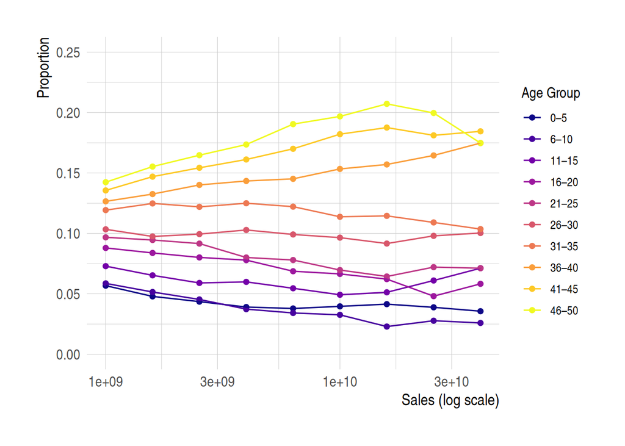

```r
frac_tb_plot_f <- \(x){x |>
  ggplot(aes(criteria, n_ratio, color = age_class)) +
    geom_point() +
    geom_line() +
    scale_color_viridis_d(
      option = "C",
      labels = age_class_labels) +
    scale_x_log10() +
    labs(
      x = "Sales (log scale)",
      y = "Proportion",
      color = "Age Group"
    ) +
    theme(axis.title = element_text(face = "bold"))
}

frac2_tb |>
  filter(n_total > 200,
         age_class != "age_other") |>
  frac_tb_plot_f() + ylim(c(0, .25))
ggsave(filename = "frac2_age.png", path = "graph")
```